# MLLA - Group Assignment

Goswin Nibbering - 563285

Kylian van Noordenne - 450752

Noora Mattsson - 477100

Eline van Groningen - 414846

11/26/2020

# Introduction

The aim of this report is to develop a predictive model, based on past Airbnb listings in Amsterdam, to help new Airbnb users set competitive prices for their listings. To do so, three different models are considered. These are lasso regularized linear regression, k-nearest-neighbors, and random forest model. The best model is selected based on the predictive performance on the test set. For this purpose, the data set is split into a training and testing set. Furthermore, each of these models requires model tuning, which is completed using 10-k cross-validation on the training set.

In the following sections, the data cleaning and feature selection process is explained, after which all the three models are tuned and tested. After this, the performance of each model is assessed, and the best model is selected. Finally, the last section discusses the recommendations based on the findings.

# Setup notebook

The following libraries are used for this notebook:

```r
# Load libraries
library(tidyverse)
library(tidymodels)
library(glmnet)
library(leaps)
library(naniar)
library(skimr)
library(knitr)
library(corrplot)
library(ranger)
library(doParallel)
library(themis)
library(vip)
```

# Load data listings

```r
# Read csv with listing information
data <- read_csv(gzfile("listings.csv.gz"))
```

# **Part 1: Data Cleaning and Feature Selection**

## Select variables of interest

An important implication for variable selection is to avoid data leakages. Data leakage occurs for example when a feature is used in the predictive models, although it would not be available at the time of the prediction. All variables including information on the reviews provide information about a listing after it has been published. Including these variables could be a potential source of data leakage. Therefore, these variables are not included in the data set. Moreover, the variables including a description and summary about the listing can be analyzed using NLP (e.g. sentiment analysis). However, this is beyond the scope of the assignment. Therefore, these variables are excluded from the model. The variables below are included in the data set for further analysis and cleaning.

```r
# Generate subset with variables of interest
data_sub <- data %>%
  select(id, price, property_type, room_type, accommodates, bathrooms, bedrooms,
         beds, bed_type, amenities, host_since, host_response_time,
         host_response_rate, host_neighbourhood, host_listings_count,
         host_verifications, host_identity_verified, neighbourhood_cleansed,
         square_feet, cleaning_fee, guests_included, extra_people,
         minimum_nights, maximum_nights, availability_30, availability_60,
         availability_90, availability_365, instant_bookable,
         cancellation_policy, require_guest_profile_picture,
         require_guest_phone_verification, calculated_host_listings_count,
         calculated_host_listings_count_entire_homes,
         calculated_host_listings_count_private_rooms,
         calculated_host_listings_count_shared_rooms)
```

```r
# Inspect data
head(data_sub)
```

| id | price | property_type | room_type | accommodates | bathrooms | bedrooms | beds | bed_type | amenities | host_since | host_response_time | host_response_rate | host_neighbourhood | host_listings_count | host_verifications | host_identity_verified | neighbourhood_cleansed | square_feet | cleaning_fee | guests_included | extra_people | minimum_nights | maximum_nights | availability_30 | availability_60 | availability_90 | availability_365 | instant_bookable | cancellation_policy | … |
| --- | --- | --- | --- | --- | --- | --- | --- | --- | --- | --- | --- | --- | --- | --- | --- | --- | --- | --- | --- | --- | --- | --- | --- | --- | --- | --- | --- | --- | --- | --- |
| 2818 | $59.00 | Apartment | Private room | 2 | 1.5 | 1 | 2 | Real Bed | {Internet,Wifi,"Paid parking off premises","Buzzer/wireless intercom",Heating,Washer,"Smoke detector","Carbon monoxide detector","First aid kit","Safety card","Fire extinguisher",Essentials,Shampoo,"L… | 2008-09-24 | within an hour | 100% | Indische Buurt | 1 | ['email', 'phone', 'reviews', 'jumio', 'offline_government_id', 'selfie', 'government_id', 'identity_manual'] | FALSE | Oostelijk Havengebied - Indische Buurt | NA | $60.00 | 1 | $20.00 | 3 | 15 | 0 | 0 | 0 | 0 | TRUE | strict_14_with_grace_period | … |
| 20168 | $80.00 | Townhouse | Private room | 2 | 1.0 | 1 | 1 | Real Bed | {TV,Internet,Wifi,"Paid parking off premises",Heating,"Smoke detector","Carbon monoxide detector","Fire extinguisher",Essentials,Hangers,"Hair dryer","Laptop friendly workspace","translation missing: … | 2009-12-02 | within an hour | 100% | Grachtengordel | 2 | ['email', 'phone', 'reviews', 'jumio', 'offline_government_id', 'selfie', 'government_id', 'identity_manual'] | FALSE | Centrum-Oost | NA | NA | 2 | $0.00 | 1 | 1000 | 4 | 21 | 51 | 198 | FALSE | strict_14_with_grace_period | … |
| 25428 | $125.00 | Apartment | Entire home/apt | 3 | 1.0 | 1 | 1 | Real Bed | {TV,"Cable TV",Internet,Wifi,Kitchen,Elevator,"Indoor fireplace","Buzzer/wireless intercom",Heating,"Family/kid friendly",Washer,Dryer,"Smoke detector","Fire extinguisher",Essentials,Shampoo,Hangers,"… | 2009-11-20 | within an hour | 100% | Grachtengordel | 2 | ['email', 'phone', 'reviews'] | FALSE | Centrum-West | NA | $40.00 | 2 | $10.00 | 14 | 60 | 2 | 26 | 26 | 71 | FALSE | strict_14_with_grace_period | … |
| 27886 | $155.00 | Houseboat | Private room | 2 | 1.0 | 1 | 1 | Real Bed | {TV,Internet,Wifi,Breakfast,Heating,"Smoke detector","Carbon monoxide detector","Fire extinguisher",Essentials,Shampoo,"24-hour check-in",Hangers,"Hair dryer","Laptop friendly workspace","translation … | 2010-03-23 | within an hour | 100% | Westelijke Eilanden | 1 | ['email', 'phone', 'reviews', 'jumio'] | TRUE | Centrum-West | NA | $0.00 | 1 | $0.00 | 2 | 730 | 16 | 43 | 69 | 251 | TRUE | strict_14_with_grace_period | … |
| 28871 | $75.00 | Apartment | Private room | 2 | 1.0 | 1 | 1 | Real Bed | {Internet,Wifi,"Pets live on this property",Cat(s),Heating,Washer,Dryer,"Smoke detector","Fire extinguisher",Essentials,Shampoo,"Lock on bedroom door",Hangers,"Hair dryer","Private entrance","Hot wate… | 2010-05-13 | within an hour | 100% | Amsterdam Centrum | 3 | ['email', 'phone', 'reviews', 'jumio'] | TRUE | Centrum-West | NA | NA | 1 | $0.00 | 2 | 1825 | 0 | 2 | 10 | 134 | FALSE | moderate | … |
| 29051 | $55.00 | Apartment | Private room | 1 | 1.0 | 1 | 1 | Real Bed | {Internet,Wifi,"Smoking allowed","Pets allowed",Heating,Washer,Dryer,"Smoke detector","Fire extinguisher",Essentials,Shampoo,"Lock on bedroom door","Hair dryer","translation missing: en.hosting_amenit… | 2010-05-13 | within an hour | 100% | Amsterdam Centrum | 3 | ['email', 'phone', 'reviews', 'jumio'] | TRUE | Centrum-West | NA | NA | 1 | $0.00 | 2 | 730 | 0 | 0 | 0 | 0 | FALSE | moderate | … |

```r
# Inspect data
skim(data_sub) %>% knit_print()
```

Data summary

| Name | data_sub |
| --- | --- |
| Number of rows | 20025 |
| Number of columns | 36 |
| _______________________ |  |
| Column type frequency: |  |
| character | 13 |
| Date | 1 |
| logical | 4 |
| numeric | 18 |
| ________________________ |  |
| Group variables | None |

**Variable type: character**

| skim_variable | n_missing | complete_rate | min | max | empty | n_unique | whitespace |
| --- | --- | --- | --- | --- | --- | --- | --- |
| price | 0 | 1.00 | 5 | 9 | 0 | 479 | 0 |
| property_type | 0 | 1.00 | 3 | 22 | 0 | 34 | 0 |
| room_type | 0 | 1.00 | 10 | 15 | 0 | 4 | 0 |
| bed_type | 0 | 1.00 | 5 | 13 | 0 | 5 | 0 |
| amenities | 0 | 1.00 | 2 | 1303 | 0 | 19213 | 0 |
| host_response_time | 158 | 0.99 | 3 | 18 | 0 | 5 | 0 |
| host_response_rate | 158 | 0.99 | 2 | 4 | 0 | 61 | 0 |
| host_neighbourhood | 5972 | 0.70 | 4 | 35 | 0 | 81 | 0 |
| host_verifications | 0 | 1.00 | 2 | 158 | 0 | 381 | 0 |
| neighbourhood_cleansed | 0 | 1.00 | 4 | 38 | 0 | 22 | 0 |
| cleaning_fee | 3604 | 0.82 | 5 | 7 | 0 | 112 | 0 |
| extra_people | 0 | 1.00 | 5 | 7 | 0 | 112 | 0 |
| cancellation_policy | 0 | 1.00 | 8 | 27 | 0 | 5 | 0 |

**Variable type: Date**

| skim_variable | n_missing | complete_rate | min | max | median | n_unique |
| --- | --- | --- | --- | --- | --- | --- |
| host_since | 158 | 0.99 | 2008-09-24 | 2019-12-06 | 2015-02-08 | 3133 |

**Variable type: logical**

| skim_variable | n_missing | complete_rate | mean | count |
| --- | --- | --- | --- | --- |
| host_identity_verified | 158 | 0.99 | 0.39 | FAL: 12094, TRU: 7773 |
| instant_bookable | 0 | 1.00 | 0.26 | FAL: 14839, TRU: 5186 |
| require_guest_profile_picture | 0 | 1.00 | 0.01 | FAL: 19819, TRU: 206 |
| require_guest_phone_verification | 0 | 1.00 | 0.01 | FAL: 19758, TRU: 267 |

**Variable type: numeric**

| skim_variable | n_missing | complete_rate | mean | sd | p0 | p25 | p50 | p75 | p100 | hist |
| --- | --- | --- | --- | --- | --- | --- | --- | --- | --- | --- |
| id | 0 | 1.00 | 19117026.00 | 11473019.80 | 2818 | 9631819 | 18418621 | 27913527.0 | 40655209 | ▇▇▇▅▆ |
| accommodates | 0 | 1.00 | 2.87 | 1.30 | 1 | 2 | 2 | 4.0 | 18 | ▇▁▁▁▁ |
| bathrooms | 6 | 1.00 | 1.18 | 0.39 | 0 | 1 | 1 | 1.5 | 8 | ▇▁▁▁▁ |
| bedrooms | 13 | 1.00 | 1.45 | 0.89 | 0 | 1 | 1 | 2.0 | 12 | ▇▁▁▁▁ |
| beds | 31 | 1.00 | 1.79 | 1.41 | 0 | 1 | 1 | 2.0 | 32 | ▇▁▁▁▁ |
| host_listings_count | 158 | 0.99 | 3.85 | 28.93 | 0 | 1 | 1 | 1.0 | 751 | ▇▁▁▁▁ |
| square_feet | 19662 | 0.02 | 542.88 | 560.24 | 0 | 0 | 484 | 834.0 | 3229 | ▇▅▁▁▁ |
| guests_included | 0 | 1.00 | 1.46 | 0.95 | 1 | 1 | 1 | 2.0 | 16 | ▇▁▁▁▁ |
| minimum_nights | 0 | 1.00 | 3.43 | 14.74 | 1 | 2 | 2 | 3.0 | 1001 | ▇▁▁▁▁ |
| maximum_nights | 0 | 1.00 | 613.89 | 548.62 | 1 | 20 | 1125 | 1125.0 | 11250 | ▇▁▁▁▁ |
| availability_30 | 0 | 1.00 | 4.46 | 7.81 | 0 | 0 | 0 | 6.0 | 30 | ▇▁▁▁▁ |
| availability_60 | 0 | 1.00 | 10.05 | 17.14 | 0 | 0 | 0 | 13.0 | 60 | ▇▁▁▁▁ |
| availability_90 | 0 | 1.00 | 15.69 | 26.77 | 0 | 0 | 0 | 19.0 | 90 | ▇▁▁▁▁ |
| availability_365 | 0 | 1.00 | 47.93 | 95.34 | 0 | 0 | 0 | 37.0 | 365 | ▇▁▁▁▁ |
| calculated_host_listings_count | 0 | 1.00 | 1.97 | 5.20 | 1 | 1 | 1 | 1.0 | 72 | ▇▁▁▁▁ |
| calculated_host_listings_count_entire_homes | 0 | 1.00 | 1.50 | 5.06 | 0 | 1 | 1 | 1.0 | 72 | ▇▁▁▁▁ |
| calculated_host_listings_count_private_rooms | 0 | 1.00 | 0.38 | 1.08 | 0 | 0 | 0 | 0.0 | 16 | ▇▁▁▁▁ |
| calculated_host_listings_count_shared_rooms | 0 | 1.00 | 0.01 | 0.09 | 0 | 0 | 0 | 0.0 | 3 | ▇▁▁▁▁ |

## Data cleaning

### Basic cleaning

First, we converted all categorical and logical variables, which did not need any further cleaning, to a data type factor.

```r
# Convert categorical vars to factors
data_sub$property_type <- factor(data_sub$property_type ,
                                 levels = unique(data_sub$property_type))
data_sub$room_type <- factor(data_sub$room_type ,
                             levels = unique(data_sub$room_type))
data_sub$bed_type <- factor(data_sub$bed_type ,
                    levels = unique(data_sub$bed_type))
data_sub$host_response_time <- factor(data_sub$ host_response_time,
                    levels = unique(data_sub$host_response_time))
data_sub$host_neighbourhood <- factor(data_sub$host_neighbourhood,
                    levels = unique(data_sub$host_neighbourhood))
data_sub$neighbourhood_cleansed <- factor(data_sub$neighbourhood_cleansed,
                    levels = unique(data_sub$neighbourhood_cleansed))
data_sub$cancellation_policy <- factor(data_sub$cancellation_policy ,
                    levels = unique(data_sub$cancellation_policy))

# Convert logical variables to factors
data_sub$host_identity_verified <- factor(data_sub$host_identity_verified)
data_sub$instant_bookable <- factor(data_sub$instant_bookable)
data_sub$require_guest_profile_picture <-
  factor(data_sub$require_guest_profile_picture)
data_sub$require_guest_phone_verification <-
  factor(data_sub$require_guest_phone_verification)
```

Second, some of the variables contain numeric variables, however, they are stored in a string containing a dollar or percentage sign. The signs were removed from the strings, and the remaining numbers were converted to numeric variables.

```r
# Remove $ sign from columns containing prices and convert to doubles
data_sub$price <- as.double(gsub("[,$]", "", data_sub$price))
data_sub$cleaning_fee <- as.double(gsub("[,$]", "", data_sub$cleaning_fee))
data_sub$extra_people <- as.double(gsub("[,$]", "", data_sub$extra_people))

# Replace "N/A" values, remove % and convert to percentage
data_sub$host_response_rate <- na_if(data_sub$host_response_rate, "N/A")
data_sub$host_response_rate <-
  as.double(gsub("[%]", "", data_sub$host_response_rate)) / 100
```

### Clean amenities

The variable *amenities* contains all the amenities of the listing. However, this was stored in one large string, and the elements could not be accessed separately. Therefore, we cleaned the string and split it into a list containing the separated elements. Furthermore, we extracted all unique amenities and stored these in a vector.

```r
# Clean and split strings for amenities
# Returns a list with all unique values
clean_amenities <- function(x) {
  subbed <- gsub('[{}\"]', "", tolower(x))
  splitted <- str_split(subbed, ",")
  clean <- sapply(splitted, function(x) str_trim(x, side = "both"))
  return(clean)
}

# Clean amenities
data_sub$amenities_clean <-
  sapply(data_sub$amenities, function(x) clean_amenities(x))

# Create vector with all unique amenities
amenities_unique = c()
for(amenities in data_sub$amenities_clean) {
  for(element in amenities) {
    if(!(element %in% amenities_unique) & element != "") {
      amenities_unique <- append(amenities_unique, str_trim(element))
    }
  }
}
amenities_unique
```

```
##   [1] "internet"
##   [2] "wifi"
##   [3] "paid parking off premises"
##   [4] "buzzer/wireless intercom"
##   [5] "heating"
##   [6] "washer"
##   [7] "smoke detector"
##   [8] "carbon monoxide detector"
##   [9] "first aid kit"
##  [10] "safety card"
##  [11] "fire extinguisher"
##  [12] "essentials"
##  [13] "shampoo"
##  [14] "lock on bedroom door"
##  [15] "24-hour check-in"
```

[output cut: 117 more lines]

#### Create new variables based information stored in amenities

Separate variables could be created from the vector containing all unique amenities. However, since there are 130 usable amenities it seemed beyond the scope of the assignment. Moreover, some of the amenities contain information that is also given by other variables or about other amenities. For example, a private bathroom could also be a strong indicator that the listing is an entire house/apartment. Also, shampoo or shower gel could be strong indicators for the presence of a bathroom. Furthermore, some amenities are very specific and apply only to a few or one house. Yet, variables are created for some of the amenities that could have an influence on the price of a listing. We created variables for *wifi*, *pool*, *hot_tub*, and *tv*.

```r
# Create variable for WIFI and add to data set
wifi <- vector()
for(i in 1:length(data_sub$amenities_clean)) {
  if("wifi" %in% data_sub$amenities_clean[[i]] |
     "internet" %in% data_sub$amenities_clean[[i]]) {
    wifi[i] <-  "yes"
  } else {
    wifi[i] <-  "no"
  }
}
data_sub$wifi <- wifi
data_sub$wifi <- factor(data_sub$wifi, levels = c("yes", "no"))

# Create variable for pool and add to data set
pool <- vector()
for(i in 1:length(data_sub$amenities_clean)) {
  if("pool" %in% data_sub$amenities_clean[[i]] |
     "pool with pool hoist" %in% data_sub$amenities_clean[[i]]) {
    pool[i] <-  "yes"
  } else {
    pool[i] <-  "no"
  }
}
data_sub$pool <- pool
data_sub$pool <- factor(data_sub$pool, levels = c("yes", "no"))

# Create variable for hot_tub and add to data set
hot_tub <- vector()
for(i in 1:length(data_sub$amenities_clean)) {
  if("hot tub" %in% data_sub$amenities_clean[[i]]) {
    hot_tub[i] <-  "yes"
  } else {
    hot_tub[i] <-  "no"
  }
}
data_sub$hot_tub <- hot_tub
data_sub$hot_tub <- factor(data_sub$hot_tub, levels = c("yes", "no"))

# Create variable for hot_tub and add to data set
tv <- vector()
for(i in 1:length(data_sub$amenities_clean)) {
  if("tv" %in% data_sub$amenities_clean[[i]] |
     "cable tv" %in% data_sub$amenities_clean[[i]]) {
    tv[i] <-  "yes"
  } else {
    tv[i] <-  "no"
  }
}
data_sub$tv <- tv
data_sub$tv <- factor(data_sub$tv, levels = c("yes", "no"))
```

### Clean host verification methods

The same reasoning from the *amenities* section above applies to the variable *host_verification*. The same cleaning method was used as for amenities, first, we cleaned and split the strings, thereafter a vector with all unique host verification methods is generated.

```r
# Clean and split strings for host verification methods
# Returns a list with all unique values
clean_verficiations <- function(x) {
  subbed <- gsub("\\[|\\]", "", tolower(x))
  subbed_complete <- gsub("[']", "", subbed)
  splitted <- str_split(subbed_complete, ",")
  clean <- sapply(splitted, function(x) str_trim(x, side = "both"))
  return(clean)
}

# Clean host_verifications
data_sub$host_verifications_clean <-
  sapply(data_sub$host_verifications, function(x) clean_verficiations(x))

# Generate list with all unique host verification methods
verifications_unique = c()
for(verifications in data_sub$host_verifications_clean) {
  for(element in verifications) {
    if(!(element %in% verifications_unique) & element != "") {
      verifications_unique <- append(verifications_unique, str_trim(element))
    }
  }
}
verifications_unique
```

```
##  [1] "email"                 "phone"                 "reviews"
##  [4] "jumio"                 "offline_government_id" "selfie"
##  [7] "government_id"         "identity_manual"       "facebook"
## [10] "work_email"            "none"                  "google"
## [13] "manual_offline"        "manual_online"         "sent_id"
## [16] "kba"                   "weibo"                 "zhima_selfie"
## [19] "sesame"                "sesame_offline"
```

#### Create variables based on information stored in host verifications

Separate variables are created for the most common methods of verification, namely *email*, *phone*, *facebook*, and *government_id*.

```r
# Create variable for host email and add to data set
host_email <- vector()
for(i in 1:length(data_sub$host_verifications_clean)) {
  if("email" %in% data_sub$host_verifications_clean[[i]]) {
    host_email[i] <-  "yes"
  } else {
    host_email[i] <-  "no"
  }
}
data_sub$host_email <- host_email
data_sub$host_email <- factor(data_sub$host_email, levels = c("yes", "no"))

# Create variable for phone and add to data set
host_phone <- vector()
for(i in 1:length(data_sub$host_verifications_clean)) {
  if("phone" %in% data_sub$host_verifications_clean[[i]]) {
    host_phone[i] <-  "yes"
  } else {
    host_phone[i] <-  "no"
  }
}
data_sub$host_phone <- host_phone
data_sub$host_phone <- factor(data_sub$host_phone, levels = c("yes", "no"))

# Create variable for host facebook and add to data set
host_facebook <- vector()
for(i in 1:length(data_sub$host_verifications_clean)) {
  if("facebook" %in% data_sub$host_verifications_clean[[i]]) {
    host_facebook[i] <-  "yes"
  } else {
    host_facebook[i] <-  "no"
  }
}
data_sub$host_facebook <- host_facebook
data_sub$host_facebook <-
  factor(data_sub$host_facebook, levels = c("yes", "no"))

# Create variable for government id
host_government_id <- vector()
for(i in 1:length(data_sub$host_verifications_clean)) {
  if("government_id" %in% data_sub$host_verifications_clean[[i]]) {
    host_government_id[i] <-  "yes"
  } else {
    host_government_id[i] <-  "no"
  }
}
data_sub$host_government_id <- host_government_id
data_sub$host_government_id <-
  factor(data_sub$host_government_id, levels = c("yes", "no"))
```

### Clean date variables

We used the variable *host_since* to create a new variable *host_years_active*, which contains information regarding the number of years a host has been active on the platform.

```r
# Create new variable for active years host
data_sub <- data_sub %>%
  mutate(host_years_active =
           as.double(as.Date("2019-12-07") - host_since) / 365)
```

### Inspect availability variables

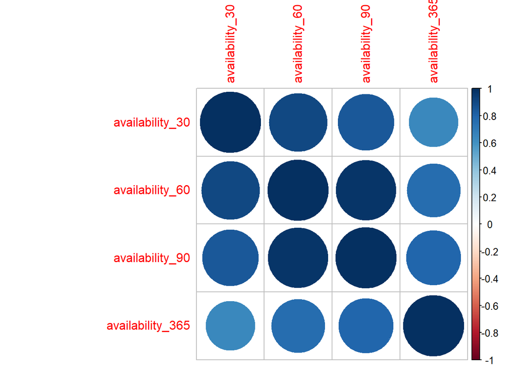

```r
# Plot correlation matrix
data_sub %>% select_if(is.numeric) %>%
  select(availability_30, availability_60, availability_90, availability_365) %>%
  cor() %>% corrplot()
```

```r
# Remove other availability variables from data set
data_sub <-
  data_sub %>%
  select(-availability_60, -availability_90, -availability_365)
```

### Check missing data

In order to inspect which variables have missing cases, and how many there are in general, a table is constructed. The table shows the variables in the data set which contain missing values (in descending order). The table shows that the variable *square_feet* has $19662$ missing cases, which is about $98.19\%$. If we would have deleted the missing cases, the data set will barely contain any data. Moreover, other methods for handling missing values, like replacing NA-values with the mean or median, would not be appropriate as the variables will be based on only $1.81\%$ of the data. Therefore, *square_feet* is not included in the final. The variable *host_response_rate* has $9349$ missing cases, which is about $46.69\%$. The variable *host_neighbourhood* has $5972$, which is about $29.82\%$. The variable *cleaning_fee* has $3604$, which is about $18.00\%$. The variables *host_response_rate*, *host_neighbourhood*, and *cleaning_fee* do not have as many missing values as *square_feet*, however, the same reasoning applies. Due to these findings, these variables are also excluded from the analyses.

```r
# Count missing cases per variable
na_counter <- sapply(data_sub, function(x) sum(is.na(x)))
vars <- colnames(data_sub)

# Extract all variables with NA-values
na_values <- tibble(variables = vars, na_count = na_counter)

# Check na count per variable
na_values %>%
  filter(na_count > 0) %>%
  arrange(desc(na_count))
```

| variables | na_count |
| --- | --- |
| square_feet | 19662 |
| host_response_rate | 9349 |
| host_neighbourhood | 5972 |
| cleaning_fee | 3604 |
| host_since | 158 |
| host_response_time | 158 |
| host_listings_count | 158 |
| host_identity_verified | 158 |
| host_years_active | 158 |
| beds | 31 |

[output cut: 2 more lines]

Moreover, a check is performed on the number of cases that contain missing values if the other values that have missing cases would be included in the ‘final’ data set. The table below shows that there are 206 cases that contain missing values, which is about $1.03\%$ of the entire data set. Since this is a very small proportion it is not very likely that deleting these cases would have a large impact on the predictions. Furthermore, all models that will be performed cannot handle missing values. Therefore, the cases with missing values are deleted.

```r
# Compute incomplete rows
data_sub %>%
  select(host_since, host_response_time, host_listings_count,
         host_identity_verified, beds, bedrooms, host_years_active,
         bathrooms) %>%
  complete.cases() %>%
  summary(count())
```

```
##    Mode   FALSE    TRUE
## logical     206   19819
```

## Final data set

```r
# Select variables for data set
variables_analysis <-
  na_values %>%
  filter(na_count <= 158) %>%
  select(variables) %>%
  pull(variables)

# Create final data set
data_semi_final <- data_sub %>% select(all_of(variables_analysis))
data_semi_final <- data_semi_final %>%
  select(-c(amenities, amenities_clean, host_verifications,
            host_verifications_clean, host_since))
data_final <- data_semi_final[complete.cases(data_semi_final), ]
```

| Variable Name | Variable Description |
| --- | --- |
| id | Listing ID |
| price | Log transformed price listing (€) |
| property_type | Type of property that is rented out |
| room_type | Type of room that is rented out |
| accommodates | Number of people that can be accommodated in the rented property |
| bathrooms | Number of bathrooms in the property |
| bedrooms | Number of bedrooms in the property |
| beds | Number of beds in the property |
| bed_type | Type of bed present within the property |
| host_listings_count | Number of total listings of a host |
| host_response_time | Average time it takes for a host to respond |
| host_identity_verified | Whether a host verified his identity on Airbnb |
| neighbourhood_cleansed | Neighborhood location of the listed property |
| guests_included | Number of guests included within a listing |
| extra_people | Number of extra people allowed at the listing |
| minimum_nights | The minimum amount of nights that a guest has to book regarding this listing |
| maximum_nights | The maximum amount of nights that a guest is allowed to book regarding this listing |
| availability_30 | The number of days for which a particular host is available in 30 days |
| instant_bookable | Whether guests can directly book without an inquiry |
| cancellation_policy | The set policy regarding guest cancellation |
| require_guest_profile_picture | Whether the potential guest needs a profile picture in order to book the listing |
| require_guest_phone_verification | Whether the potential guest needs a phone verification in order to book the listing |
| calculated_host_listings_count | The number of total host listings |
| calculated_host_listings_count_entire_homes | The number of total entire home listings of a specific host |
| calculated_host_listings_count_private_rooms | The number of total private room listings of a specific host |
| calculated_host_listings_count_shared_rooms | The number of total shared room listings of a specific host |
| wifi | Whether WiFi is present within the property |
| pool | Whether a pool is present within the property |
| hot_tub | Whether a hot tub is present within the property |
| tv | Whether a tv is present within the property |
| host_email | Whether the host verified his email on Airbnb |
| host_phone | Whether the host verified his phone on Airbnb |
| host_facebook | Whether the host verified his Facebook account on Airbnb |
| host_government_id | Whether the host verified his government ID on Airbnb |
| host_years_active | Number of years the host is active on Airbnb |

## Create train-test split

For further analysis, the data is split into a train-test set.

```r
# Create a train-split sets
seed_x <-  123
set.seed(seed_x)
data_split <- initial_split(data_final, prop = 0.7)
data_train <- training(data_split)
data_test <- testing(data_split)
```

### Inspecting the predicted variable

In order to prevent data leakages, we only inspect the predicted variable *price* in the training set. In order to inspect *price*, we have created a distribution plot. The plot shows that the data set contains some outliers and that the distribution is rightly skewed. Both the outliers and the skewness make the data less interpretable and this could have an influence on the performance of the models.

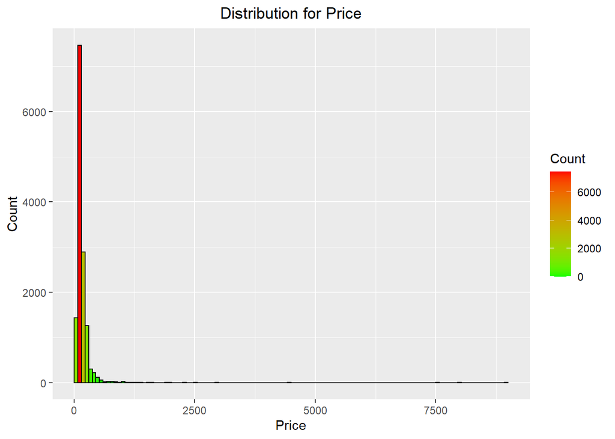

```r
# Plot distribution price
ggplot(data = data_train , aes(price)) +
  geom_histogram(col="black",
                 breaks=seq(0, max(data_train$price), by=75),
                 aes(fill=..count..)) +
  labs(title="Distribution for Price", x="Price", y="Count") +
  scale_fill_gradient("Count", low="green", high="red") +
  theme(plot.title = element_text(hjust = 0.5))
```

In order to prevent these potential problems, we created a new distribution plot with a log-transformed variable *price*. The plot shows that the distribution is less skewed and does not contain many large outliers. Consequently, the data is more interpretable. Therefore, we will use the log-transformed *price* for our models.

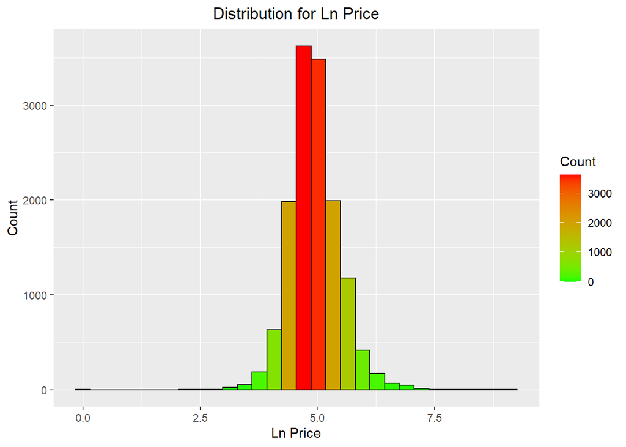

```r
# Plot distribution price
ggplot(data = data_train , aes(log(price + 1))) +
  geom_histogram(col="black",
                 aes(fill=..count..)) +
  labs(title="Distribution for Ln Price", x="Ln Price", y="Count") +
  scale_fill_gradient("Count", low="green", high="red") +
  theme(plot.title = element_text(hjust = 0.5))
```

```r
# Log transform the price in for both training and test set
data_final$price <- log(data_final$price + 1)

# Resplit the data using the same seed
set.seed(seed_x)
data_split <- initial_split(data_final, prop = 0.7)
data_train <- training(data_split)
data_test <- testing(data_split)
```

### K-fold cross validation

Moreover, we have generated 10-fold cross validation sets.

```r
# Generate 10-fold CV sets
set.seed(321)
data_folds <- vfold_cv(data_train, v = 10)
data_folds
```

| splits | id |
| --- | --- |
|  | Fold01 |
|  | Fold02 |
|  | Fold03 |
|  | Fold04 |
|  | Fold05 |
|  | Fold06 |
|  | Fold07 |
|  | Fold08 |
|  | Fold09 |
|  | Fold10 |

```r
# Remove data frames to avoid leakages and errors
rm(data)
rm(data_sub)
rm(data_semi_final)
rm(na_values)
```

# **Part 2: Modelling Approaches**

## Linear Lasso Regularized Regression Model

In this section, a regularized regression model will be specified and trained. A lasso penalty is chosen to simultaneously perform subset selection. Therefore, a mixture is set to 1 in the model specification.

### Model specification

```r
# Specify the model and engine used
lasso_linreg <- linear_reg(penalty = tune(), mixture = 1) %>%
  set_engine("glmnet")

# Check that model specified correctly:
lasso_linreg %>% translate()
```

### Preprocessing recipe

In this section, the recipe is formulated. All the final dataset variables are included in the recipe, in order to perform the subset selection by means of a lasso penalty. As the property type and bed type have some categories with just a few observations, the categories that include less than 1% of the total number of observations are combined to “other” category to avoid sparse data. Additionally, dummies are created for all of the nominal variables. Lastly, all the variables are normalized.

```r
# Prepare the recipe by setting up the regression model, setting id as id variable, combining small categories to other class, and creating dummies and normalizing variables
lasso_recipe <-  recipe(price ~ .,
                          data = data_train) %>%
                        update_role(id, new_role = "ID") %>%
                        step_other(property_type, bed_type,  threshold = 0.01, other = "other values") %>%
                        step_dummy(all_nominal(), -all_outcomes()) %>%
                        step_normalize(all_predictors(), -all_outcomes())
lasso_recipe
```

Testing that this works properly:

```r
# Prepare and bake the data (on training set) to check that the recipe prepares the data correctly
data_baked <- lasso_recipe %>% prep(data_train) %>% bake(data_train)
head(data_baked)
```

| id | accommodates | bathrooms | bedrooms | beds | host_listings_count | guests_included | extra_people | minimum_nights | maximum_nights | availability_30 | calculated_host_listings_count | calculated_host_listings_count_entire_homes | calculated_host_listings_count_private_rooms | calculated_host_listings_count_shared_rooms | host_years_active | price | property_type_Townhouse | property_type_Houseboat | property_type_Bed.and.breakfast | property_type_House | property_type_Boat | property_type_Condominium | property_type_Loft | property_type_other.values | room_type_Entire.home.apt | room_type_Hotel.room | room_type_Shared.room | bed_type_other.values | host_response_time_N.A | … |
| --- | --- | --- | --- | --- | --- | --- | --- | --- | --- | --- | --- | --- | --- | --- | --- | --- | --- | --- | --- | --- | --- | --- | --- | --- | --- | --- | --- | --- | --- | --- |
| 2818 | -0.66877194 | 0.7944714 | -0.5085872 | 0.1429932 | -0.09793191 | -0.4766491 | 0.36062759 | -0.02834967 | -1.0945944 | -0.56749871 | -0.186286433 | -0.29481379 | 0.5711698 | -0.06279119 | 3.251030 | 4.094345 | -0.1853838 | -0.1306891 | -0.1453328 | -0.3033223 | -0.1304035 | -0.1362825 | -0.1390008 | -0.1790502 | -1.8786409 | -0.1263429 | -0.05170877 | -0.08980268 | -0.9331437 | … |
| 20168 | -0.66877194 | -0.4623697 | -0.5085872 | -0.5511592 | -0.06308075 | 0.5576063 | -0.47327751 | -0.16652753 | 0.6924410 | -0.05481075 | 0.003015403 | -0.29481379 | 1.4886654 | -0.06279119 | 2.658389 | 4.394449 | 5.3938249 | -0.1306891 | -0.1453328 | -0.3033223 | -0.1304035 | -0.1362825 | -0.1390008 | -0.1790502 | -1.8786409 | -0.1263429 | -0.05170877 | -0.08980268 | -0.9331437 | … |
| 25428 | 0.09345117 | -0.4623697 | -0.5085872 | -0.5511592 | -0.06308075 | 0.5576063 | -0.05632496 | 0.73162858 | -1.0129532 | -0.31115473 | 0.003015403 | 0.09362368 | -0.3463258 | -0.06279119 | 2.674776 | 4.836282 | -0.1853838 | -0.1306891 | -0.1453328 | -0.3033223 | -0.1304035 | -0.1362825 | -0.1390008 | -0.1790502 | 0.5322613 | -0.1263429 | -0.05170877 | -0.08980268 | -0.9331437 | … |
| 27886 | -0.66877194 | -0.4623697 | -0.5085872 | -0.5511592 | -0.09793191 | -0.4766491 | -0.47327751 | -0.09743860 | 0.2025937 | 1.48325310 | -0.186286433 | -0.29481379 | 0.5711698 | -0.06279119 | 2.506815 | 5.049856 | -0.1853838 | 7.6511989 | -0.1453328 | -0.3033223 | -0.1304035 | -0.1362825 | -0.1390008 | -0.1790502 | -1.8786409 | -0.1263429 | -0.05170877 | -0.08980268 | -0.9331437 | … |
| 29051 | -1.43099505 | -0.4623697 | -0.5085872 | -0.5511592 | -0.02822959 | -0.4766491 | -0.47327751 | -0.09743860 | 0.2025937 | -0.56749871 | 0.192317240 | -0.29481379 | 2.4061610 | -0.06279119 | 2.437173 | 4.025352 | -0.1853838 | -0.1306891 | -0.1453328 | -0.3033223 | -0.1304035 | -0.1362825 | -0.1390008 | -0.1790502 | -1.8786409 | -0.1263429 | -0.05170877 | -0.08980268 | -0.9331437 | … |
| 41125 | -0.66877194 | -0.4623697 | -0.5085872 | -0.5511592 | -0.09793191 | 0.5576063 | 2.65386661 | -0.02834967 | -1.0583094 | 0.20153322 | -0.186286433 | -0.10059506 | -0.3463258 | -0.06279119 | 2.340221 | 5.198497 | -0.1853838 | -0.1306891 | -0.1453328 | -0.3033223 | -0.1304035 | -0.1362825 | -0.1390008 | -0.1790502 | 0.5322613 | -0.1263429 | -0.05170877 | -0.08980268 | -0.9331437 | … |

### Create Lasso Workflow

```r
# Combine the model specification and reciple to a workflow
lasso_wf <- workflow() %>%
  add_recipe(lasso_recipe) %>%
  add_model(lasso_linreg)
lasso_wf
```

### Tuning grids

Next, the $\lambda$ parameter of the lasso model will be tuned. For that purpose, a tuning grid is specified.

```r
# Set tuning grid
grid_lasso <- tibble(penalty = 10^(seq(from = -5, to = 1, length.out = 70)))
```

### Tuning lasso-penalized linear regression

10-k cross-validation is used to tune the lasso-penalized linear regression, and the metrics are plotted against the different values of $\lambda$.

```r
 # Perform grid search over the tuning grid of penalty values
 lasso_tune <- lasso_wf %>%
  tune_grid(resamples = data_folds,
            grid = grid_lasso,
            metrics = metric_set(mae, rmse, rsq_trad))
```

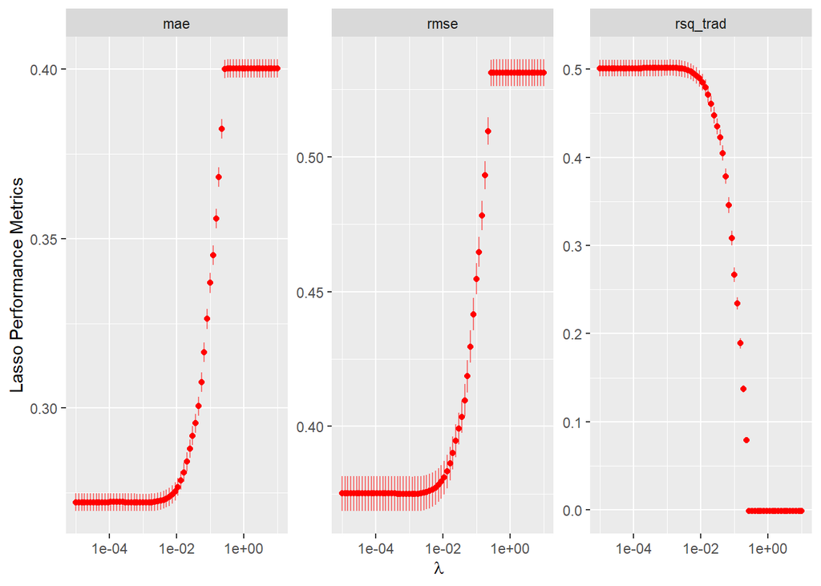

```r
# Store metrics in variable
lasso_tune_metrics <- lasso_tune %>%
  collect_metrics()

# Plot all results metrics
lasso_tune_metrics %>%
  ggplot(aes(x = penalty, y = mean,
             ymin = mean - std_err, ymax = mean + std_err)) +
  geom_linerange(alpha = 0.5, colour = "red") +
  geom_point(colour = "red") +
   facet_wrap(~ .metric, scale = "free_y") +
  scale_x_log10() +
  labs(y = "Lasso Performance Metrics", x = expression(lambda))
```

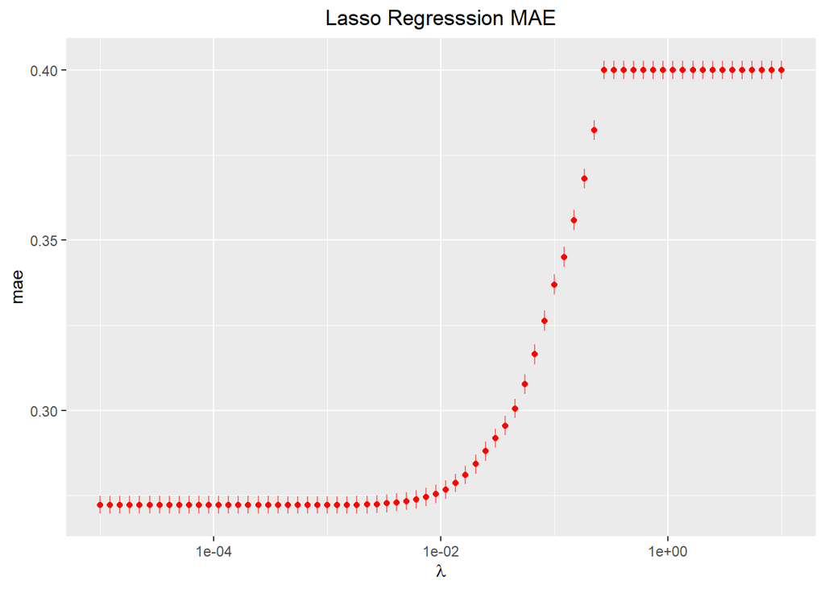

```r
# Plot MAE
lasso_tune_metrics %>% filter(.metric == "mae") %>%
  ggplot(aes(x = penalty, y = mean,
             ymin = mean - std_err, ymax = mean + std_err)) +
  geom_linerange(alpha = 0.5, colour = "red") +
  geom_point(colour = "red") +
  scale_x_log10() +
  labs(y = "mae", x = expression(lambda),
       title = "Lasso Regresssion MAE") +
  theme(plot.title = element_text(hjust = 0.5))
```

Next, the Lambda value which results in best model performance on the train set is selected. It can be seen that as the RMSE is more sensitive for large residuals, the standard errors of these metrics are larger compared to the standard errors of mean absolute error (MAE). Therefore, the mean absolute error is used to select the best model.

```r
# Show best models with corresponding penalty values
lasso_tune %>% show_best("mae")
```

| penalty | .metric | .estimator | mean | n | std_err | .config |
| --- | --- | --- | --- | --- | --- | --- |
| 0.0012216773 | mae | standard | 0.2721459 | 10 | 0.002589010 | Model25 |
| 0.0010000000 | mae | standard | 0.2721476 | 10 | 0.002583512 | Model24 |
| 0.0014924955 | mae | standard | 0.2721612 | 10 | 0.002594722 | Model26 |
| 0.0008185467 | mae | standard | 0.2721661 | 10 | 0.002578071 | Model23 |
| 0.0006700188 | mae | standard | 0.2721838 | 10 | 0.002573204 | Model22 |

The best model is selected using the one standard error rule, where the simplest model that has MAE inside one standard error from the absolute best model is chosen to avoid overfitting.

```r
# Select best model according to 1 std error rule
lasso_1se_model <- select_by_one_std_err(lasso_tune, metric = "mae", desc(penalty))
lasso_1se_model
```

| penalty | .metric | .estimator | mean | n | std_err | .config | .best | .bound |
| --- | --- | --- | --- | --- | --- | --- | --- | --- |
| 0.007405685 | mae | standard | 0.2744839 | 10 | 0.002653991 | Model34 | 0.2721459 | 0.2747349 |

As can be seen, the best model has a penalty parameter of 0.007.

Finalize the workflow:

```r
# Finalize lasso wf with the selected best model
lasso_wf_tuned <-
  lasso_wf %>%
  finalize_workflow(lasso_1se_model)
lasso_wf_tuned
```

```r
# Train the tuned model on all of the train data and test on the test data
lasso_last_fit <- lasso_wf_tuned %>%
  last_fit(data_split, metrics = metric_set(mae, rmse, rsq_trad))
```

The performance on the test set for this model is:

```r
# Collect metrics from the model on the test set
lasso_test_metrics <- lasso_last_fit %>% collect_metrics()
lasso_test_metrics
```

| .metric | .estimator | .estimate |
| --- | --- | --- |
| mae | standard | 0.2722283 |
| rmse | standard | 0.3731941 |
| rsq_trad | standard | 0.4874893 |

As seen above, the final lasso model has mean absolute error of 0.27, root mean square error of 0.37 and R squared of 48,7% on the test data.

### Variable importance

To assess the importance of the predictor variables, model parameter estimates are calculated below:

```r
# Fit the model on the training data and pull the model coefficients for the variables
lasso_wf_tuned %>% fit(data_train) %>% pull_workflow_fit() %>% tidy()
```

| term | estimate | penalty |
| --- | --- | --- |
| (Intercept) | 4.9331363347 | 0.007405685 |
| accommodates | 0.1472737123 | 0.007405685 |
| bathrooms | 0.0451834052 | 0.007405685 |
| bedrooms | 0.0762121980 | 0.007405685 |
| beds | -0.0022108254 | 0.007405685 |
| host_listings_count | 0.0380116634 | 0.007405685 |
| guests_included | 0.0000000000 | 0.007405685 |
| extra_people | 0.0000000000 | 0.007405685 |
| minimum_nights | 0.0000000000 | 0.007405685 |
| maximum_nights | 0.0000000000 | 0.007405685 |

[output cut: 59 more lines]

As lasso performs subset selection automatically, some variables have a coefficient of zero. There are multiple variables with a coefficient of zero, which implies that these variables are less important for the price prediction of new Airbnb listings. The most important variables can be identified by looking at the coefficients as well, and the 4 most important variables are the number of accommodates, the number of days that the Airbnb is available inside 30 days, room type of entire home apartment, and lastly, Centrum-West neighborhood.

## Random Forest

### Recipe specification

Within this section, a random forest will be created. First, a preprocessing recipe is created. The id variable is updated to a separate role, instead of being a predictor.

```r
# Specify recipe
rf_recipe <- recipe(price ~ ., data = data_train) %>%
  update_role(id, new_role = "id var")
rf_recipe
```

```
## Data Recipe
##
## Inputs:
##
##       role #variables
##     id var          1
##    outcome          1
##  predictor         33
```

### Tuning specifications

Within this section, the tune specification are mentioned. The *mtry* is the number of features that are used at each split. The exact mtry value will be tuned later on. Different values for trees were tested (200, 500 & 1000). Increasing the number of trees did not have much impact on the results. Therefore, a tree size of 200 is chosen to save computational time.

```r
# Tune specification
rf_tune_spec <- rand_forest(mtry = tune(), trees = 200) %>%
  set_engine("ranger") %>%
  set_mode("regression")
```

The recipe and the model are combined into a workflow that can be tuned.

```r
# Workflow creation
rf_tune_wf <- workflow() %>%
  add_recipe(rf_recipe) %>%
  add_model(rf_tune_spec)
```

A metric set is specified, which calculates the *Root Mean Square Error (RMSE)*, *the Mean Absolute Error (MAE)* and the *R-squared (rsq_trad)* is created.

```r
# Class metrics specification
class_metrics <- metric_set(rmse, mae, rsq_trad)
```

The command below allows us to do computations in parallel.

```r
registerDoParallel()
```

The command grid = tibble(mtry = 1:33) was utilized, as this allows the random forest to consider all number of variables at each split. Based on the MAE criteria, a mtry of 5, 6, 7, 8 & 9 was found as the optimal solution. Afterwards, a mtry of c(1:10)) is taken that will include the optimal values, as well as mtry values of 1 up until 4 and a mtry of 10. This allows us to see that the mtry is initially increased up until it reaches its optimal mtry solution.

```r
# Define the tune grid
rf_tunegrid <- tibble(mtry = c(1:10))
```

```r
# Tune the grid
set.seed(12345)
rf_tune_res <- tune_grid(
  rf_tune_wf,
  resamples = data_folds,
  grid = rf_tunegrid,
  metrics = class_metrics
)
rf_tune_res
```

| splits | id | .metrics | .notes |
| --- | --- | --- | --- |
|  | Fold01 |  |  |
|  | Fold02 |  |  |
|  | Fold03 |  |  |
|  | Fold04 |  |  |
|  | Fold05 |  |  |
|  | Fold06 |  |  |
|  | Fold07 |  |  |
|  | Fold08 |  |  |
|  | Fold09 |  |  |
|  | Fold10 |  |  |

### Selecting tuning parameters

```r
# Collect metrics
rf_tune_res %>%
  collect_metrics()
```

| mtry | .metric | .estimator | mean | n | std_err | .config |
| --- | --- | --- | --- | --- | --- | --- |
| 1 | mae | standard | 0.3109606 | 10 | 0.002858856 | Model01 |
| 1 | rmse | standard | 0.4194122 | 10 | 0.006290146 | Model01 |
| 1 | rsq_trad | standard | 0.3762977 | 10 | 0.007988768 | Model01 |
| 2 | mae | standard | 0.2716291 | 10 | 0.002434202 | Model02 |
| 2 | rmse | standard | 0.3713230 | 10 | 0.006749893 | Model02 |
| 2 | rsq_trad | standard | 0.5111081 | 10 | 0.009586609 | Model02 |
| 3 | mae | standard | 0.2631380 | 10 | 0.002599459 | Model03 |
| 3 | rmse | standard | 0.3609150 | 10 | 0.006967176 | Model03 |
| 3 | rsq_trad | standard | 0.5380822 | 10 | 0.010261801 | Model03 |
| 4 | mae | standard | 0.2607204 | 10 | 0.002480942 | Model04 |

[output cut: 20 more lines]

This plot illustrates the best mtry, based on the criteria of the MAE. A lower MAE would indicate a better result, as a lower value indicates a lower error of prediction.

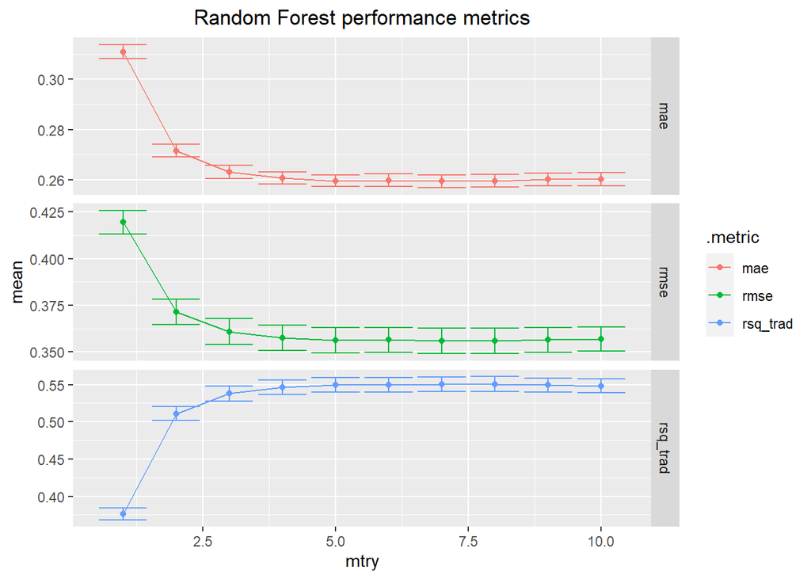

```r
# Plot results all metrics
rf_tune_res %>%
  collect_metrics() %>%
  filter(.metric %in% c("rmse", "mae", "rsq_trad")) %>%
  ggplot(aes(x = mtry, y = mean, ymin = mean - std_err, ymax = mean + std_err,
             colour = .metric)) +
  geom_errorbar() +
  geom_line() +
  geom_point() +
  facet_grid(.metric ~ ., scales = "free_y") +
  labs(title = "Random Forest performance metrics") +
  theme(plot.title = element_text(hjust = 0.5))
```

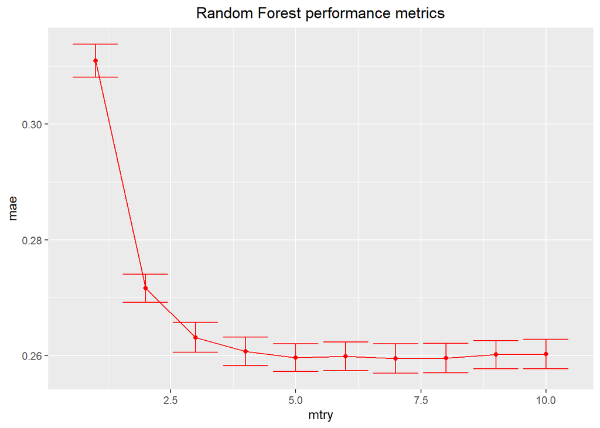

```r
# Plot the MAE based
rf_tune_res %>%
  collect_metrics() %>%
  filter(.metric == "mae") %>%
  ggplot(aes(x = mtry, y = mean, ymin = mean - std_err, ymax = mean + std_err)) +
  geom_errorbar(colour = "red") +
  geom_line(colour = "red") +
  geom_point(colour = "red") +
  labs(y = "mae", title = "Random Forest performance metrics") +
  theme(plot.title = element_text(hjust = 0.5))
```

This command will show the best mtry based on the MAE metrics.

```r
# Find the mtry with the best MAE
rf_tune_res %>% show_best("mae")
```

| mtry | .metric | .estimator | mean | n | std_err | .config |
| --- | --- | --- | --- | --- | --- | --- |
| 7 | mae | standard | 0.2595088 | 10 | 0.002534648 | Model07 |
| 8 | mae | standard | 0.2595670 | 10 | 0.002529796 | Model08 |
| 5 | mae | standard | 0.2596412 | 10 | 0.002376031 | Model05 |
| 6 | mae | standard | 0.2598822 | 10 | 0.002464020 | Model06 |
| 9 | mae | standard | 0.2601546 | 10 | 0.002422377 | Model09 |

### Best model selection

The best model based on the MAE criteria is selected and eventually finalized into the workflow.

```r
# Best model selection
best_rmse <- select_best(rf_tune_res, "mae")
final_rf <- finalize_workflow(rf_tune_wf, best_rmse)
final_rf
```

```
## == Workflow ==============================================================================================================================================================================================
## Preprocessor: Recipe
## Model: rand_forest()
##
## -- Preprocessor ------------------------------------------------------------------------------------------------------------------------------------------------------------------------------------------
## 0 Recipe Steps
##
## -- Model -------------------------------------------------------------------------------------------------------------------------------------------------------------------------------------------------
## Random Forest Model Specification (regression)
##
## Main Arguments:
##   mtry = 7
##   trees = 200
##
## Computational engine: ranger
```

#### Test set performance

Now we can train the finalized workflow on our entire training set

```r
# Finalize workflow on training set
final_res <- final_rf %>%
  last_fit(data_split, metrics = class_metrics)
```

The results based on the test set will be

```r
# Score on test data
set.seed(54321)
final_res %>%
  collect_metrics()
```

| .metric | .estimator | .estimate |
| --- | --- | --- |
| rmse | standard | 0.3487327 |
| mae | standard | 0.2550743 |
| rsq_trad | standard | 0.5524733 |

### Variable importance

Now we try to assess the variable importance. We will refit the model based on our previous tune parameters. We previously found an optimal mtry of 7, that’s why the mtry is specified as 7. However, do keep in mind that because of the random element within a random forest, this initial value might alter. We noticed that the optimal mtry switches between 6, 7 & 8.

```r
# Refit the model
rf_model_vi <- rand_forest(mtry = 7, trees = 200) %>%
  set_engine("ranger", importance = "permutation")

rf_vi_wf <- workflow() %>%
  add_model(rf_model_vi) %>%
  add_recipe(rf_recipe)

# Fit the model again
set.seed(12345)
rf_vi_fit <- rf_vi_wf %>% fit(data = data_train)
```

We can use the refitted model in order the gather the variable importance

```r
# Variable importance
rf_vi_fit %>% pull_workflow_fit() %>% vi()
```

| Variable | Importance |
| --- | --- |
| accommodates | 7.167511e-02 |
| bedrooms | 3.602413e-02 |
| neighbourhood_cleansed | 3.427250e-02 |
| room_type | 3.381970e-02 |
| beds | 2.811261e-02 |
| availability_30 | 2.745840e-02 |
| calculated_host_listings_count_private_rooms | 2.122377e-02 |
| calculated_host_listings_count_entire_homes | 1.991026e-02 |
| extra_people | 1.476515e-02 |
| guests_included | 1.178345e-02 |

[output cut: 23 more lines]

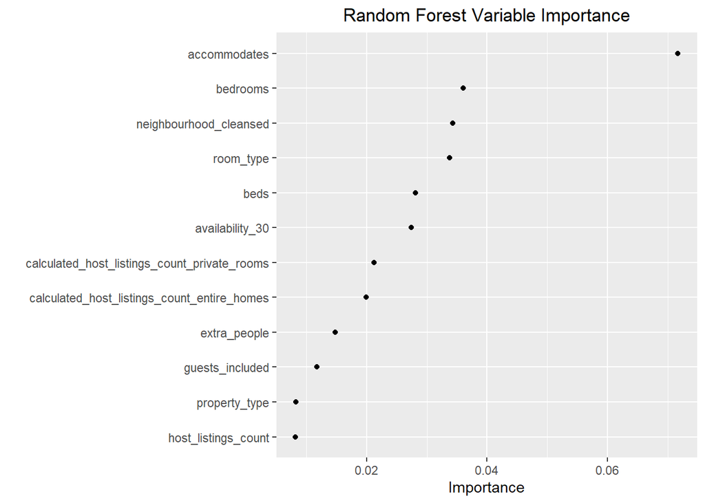

```r
# Plot variable importance
var_importance_plot <-
  rf_vi_fit %>%
  pull_workflow_fit() %>% vip(geom = "point", num_features = 12) +
  labs(title = "Random Forest Variable Importance") +
  theme(plot.title = element_text(hjust = 0.5))
var_importance_plot
```

## K-Nearest-Neighbors

### Set up turning grid

```r
# Generate tuning grid for knn
knn_tune_grid <- tibble(neighbors = 1:50*2-1)
```

### Specify workflow

Something that should be noted for this recipe is that only numeric variables are included. This is done for the reason that categorical variables with more than two levels translate with difficulty to a k-nearest neighbor algorithm. The premise of prediction based on a KNN-model is that it relies exclusively on the distance between points in the data. This distance is obvious when handling numeric variables. However, when dealing with non-numeric values and variables this distance between data points cannot easily be modeled, provided they should be modeled at all. (This will have implications for determining predictions for importance and coefficients for variables, which will be addressed at the end of the section on the KNN-model).

A mentioned, categorical variables are not included as there is no ranking within these variables. However, categorical variables with two levels, binary variables, do contain a ranking and can be utilized within the KNN-model. Our initial model included the binary variables and this yielded the following results:

| Metric | .estimate |
| --- | --- |
| rmse | 0.4156779 |
| mae | 0.3093942 |
| rsq_trad | 0.3641607 |

As the following section will show, this is a non-optimal result compared to not including the binary variables (see part 3). Therefore, it is chosen to remove all the categorical variables (implying the binary variables as well) from the KNN-model. Moreover, it should be kept in mind that how well the KNN-model works can decline when too many features are added to the model. These points are all kept in mind in specifying the recipe for the KNN-model.

```r
# Specify model
knn_mod <-
  nearest_neighbor(neighbors = tune()) %>%
  set_mode("regression") %>%
  set_engine("kknn", scale=FALSE)
knn_mod
```

```
## K-Nearest Neighbor Model Specification (regression)
##
## Main Arguments:
##   neighbors = tune()
##
## Engine-Specific Arguments:
##   scale = FALSE
##
## Computational engine: kknn
```

```r
# Specify recipe
knn_recipe <-
  recipe(price ~ ., data = data_train) %>%
  step_rm(all_nominal()) %>%
  update_role(id, new_role = "id var") %>%
  step_normalize(all_predictors(), -id)
knn_recipe
```

```
## Data Recipe
##
## Inputs:
##
##       role #variables
##     id var          1
##    outcome          1
##  predictor         33
##
## Operations:
##
## Delete terms all_nominal()
## Centering and scaling for all_predictors(), -id
```

The normalization of the data is ensured through the following commands:

```r
# Check normalization
train_baked <- knn_recipe %>% prep(data_train) %>% bake(data_train)
train_baked %>% head()
```

| id | accommodates | bathrooms | bedrooms | beds | host_listings_count | guests_included | extra_people | minimum_nights | maximum_nights | availability_30 | calculated_host_listings_count | calculated_host_listings_count_entire_homes | calculated_host_listings_count_private_rooms | calculated_host_listings_count_shared_rooms | host_years_active | price |
| --- | --- | --- | --- | --- | --- | --- | --- | --- | --- | --- | --- | --- | --- | --- | --- | --- |
| 2818 | -0.66877194 | 0.7944714 | -0.5085872 | 0.1429932 | -0.09793191 | -0.4766491 | 0.36062759 | -0.02834967 | -1.0945944 | -0.56749871 | -0.186286433 | -0.29481379 | 0.5711698 | -0.06279119 | 3.251030 | 4.094345 |
| 20168 | -0.66877194 | -0.4623697 | -0.5085872 | -0.5511592 | -0.06308075 | 0.5576063 | -0.47327751 | -0.16652753 | 0.6924410 | -0.05481075 | 0.003015403 | -0.29481379 | 1.4886654 | -0.06279119 | 2.658389 | 4.394449 |
| 25428 | 0.09345117 | -0.4623697 | -0.5085872 | -0.5511592 | -0.06308075 | 0.5576063 | -0.05632496 | 0.73162858 | -1.0129532 | -0.31115473 | 0.003015403 | 0.09362368 | -0.3463258 | -0.06279119 | 2.674776 | 4.836282 |
| 27886 | -0.66877194 | -0.4623697 | -0.5085872 | -0.5511592 | -0.09793191 | -0.4766491 | -0.47327751 | -0.09743860 | 0.2025937 | 1.48325310 | -0.186286433 | -0.29481379 | 0.5711698 | -0.06279119 | 2.506815 | 5.049856 |
| 29051 | -1.43099505 | -0.4623697 | -0.5085872 | -0.5511592 | -0.02822959 | -0.4766491 | -0.47327751 | -0.09743860 | 0.2025937 | -0.56749871 | 0.192317240 | -0.29481379 | 2.4061610 | -0.06279119 | 2.437173 | 4.025352 |
| 41125 | -0.66877194 | -0.4623697 | -0.5085872 | -0.5511592 | -0.09793191 | 0.5576063 | 2.65386661 | -0.02834967 | -1.0583094 | 0.20153322 | -0.186286433 | -0.10059506 | -0.3463258 | -0.06279119 | 2.340221 | 5.198497 |

```r
round(colMeans(train_baked, 8))
```

```
##                                           id
##                                     19106945
##                                 accommodates
##                                            0
##                                    bathrooms
##                                            0
##                                     bedrooms
##                                            0
##                                         beds
##                                            0
##                          host_listings_count
##                                            0
##                              guests_included
##                                            0
##                                 extra_people
##                                            0
##                               minimum_nights
##                                            0
##                               maximum_nights
##                                            0
##                              availability_30
##                                            0
##               calculated_host_listings_count
##                                            0
##  calculated_host_listings_count_entire_homes
##                                            0
## calculated_host_listings_count_private_rooms
##                                            0
##  calculated_host_listings_count_shared_rooms
##                                            0
##                            host_years_active
##                                            0
##                                        price
##                                            5
```

```r
round(apply(train_baked, 2, sd), 8)
```

```
##                                           id
##                                 1.141721e+07
##                                 accommodates
##                                 1.000000e+00
##                                    bathrooms
##                                 1.000000e+00
##                                     bedrooms
##                                 1.000000e+00
##                                         beds
##                                 1.000000e+00
##                          host_listings_count
##                                 1.000000e+00
##                              guests_included
##                                 1.000000e+00
##                                 extra_people
##                                 1.000000e+00
##                               minimum_nights
##                                 1.000000e+00
##                               maximum_nights
##                                 1.000000e+00
##                              availability_30
##                                 1.000000e+00
##               calculated_host_listings_count
##                                 1.000000e+00
##  calculated_host_listings_count_entire_homes
##                                 1.000000e+00
## calculated_host_listings_count_private_rooms
##                                 1.000000e+00
##  calculated_host_listings_count_shared_rooms
##                                 1.000000e+00
##                            host_years_active
##                                 1.000000e+00
##                                        price
##                                 5.313830e-01
```

```r
rm(train_baked)
```

Below the initial workflow for the k-nearest neighbors model is specified

```r
# Specify workflow
knn_workflow <-
  workflow() %>%
  add_model(knn_mod) %>%
  add_recipe(knn_recipe)
knn_workflow
```

```
## == Workflow ==============================================================================================================================================================================================
## Preprocessor: Recipe
## Model: nearest_neighbor()
##
## -- Preprocessor ------------------------------------------------------------------------------------------------------------------------------------------------------------------------------------------
## 2 Recipe Steps
##
## * step_rm()
## * step_normalize()
##
## -- Model -------------------------------------------------------------------------------------------------------------------------------------------------------------------------------------------------
## K-Nearest Neighbor Model Specification (regression)
##
## Main Arguments:
##   neighbors = tune()
##
## Engine-Specific Arguments:
##   scale = FALSE
##
## Computational engine: kknn
```

### Tuning the number of nearest neighbours

The code below serves to specify the assessment metrics that are used. Moreover, a grid search is performed using the validation sets.

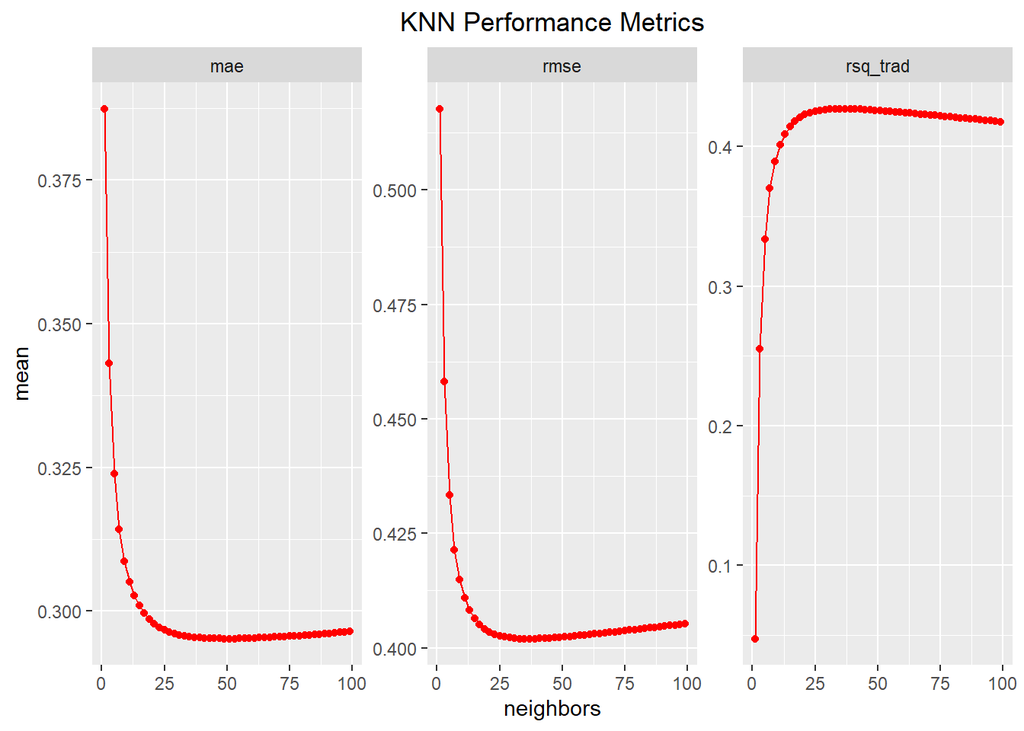

```r
# Store metrics in variable
metrics_reg <- metric_set(rmse, mae, rsq_trad)

# Perform grid search using validation sets
knn_tune_res <-
  knn_workflow %>%
  tune_grid(resamples = data_folds,
            grid = knn_tune_grid,
            metrics = metrics_reg)

# Plot results metrics
knn_metrics_plot <-
  knn_tune_res %>%  collect_metrics() %>%
  ggplot(aes(x = neighbors, y = mean)) +
  geom_point(colour = "red") + geom_line(colour = "red") +
  facet_wrap(~ .metric, scale = "free_y") +
  labs(title = "KNN Performance Metrics") +
  theme(plot.title = element_text(hjust = 0.5))
knn_metrics_plot
```

The plot output shows some metrics that plot the mean of the performance metrics. We should aim for the MAE (mean absolute error) and RMSE (root mean square error) to be as low as possible, and the rsq_trad (R-squared) to be as high as possible. We used the MAE metric to determine the optimal k-neighbors for our model, which arrived at 51 neighbors. This can be read from the MAE graph, by looking at the corresponsing k-neighbors for the lowest mean of MAE.

Moreover, from the last plot the elbow trend can somewhat clearly be seen: the metrics reach their optimum point after which the level off and slowly increase for MAE and RMSE and decrease for rqs_trad.

The model with the optimal number of k-nearest neighbors can then be selected as follows:

```r
# Generate best model
knn_best_model <- select_best(knn_tune_res, metric = "mae")
```

### Finalize workflow

Below the finalized workflow is made, which automatically picks the best KNN-model defined above (which is specified by the MAE metric)

```r
# Finalize workflow
knn_workflow_final <-
  knn_workflow %>%
  finalize_workflow(knn_best_model)
knn_workflow_final
```

```
## == Workflow ==============================================================================================================================================================================================
## Preprocessor: Recipe
## Model: nearest_neighbor()
##
## -- Preprocessor ------------------------------------------------------------------------------------------------------------------------------------------------------------------------------------------
## 2 Recipe Steps
##
## * step_rm()
## * step_normalize()
##
## -- Model -------------------------------------------------------------------------------------------------------------------------------------------------------------------------------------------------
## K-Nearest Neighbor Model Specification (regression)
##
## Main Arguments:
##   neighbors = 51
##
## Engine-Specific Arguments:
##   scale = FALSE
##
## Computational engine: kknn
```

### Last fit

A final workflow can be set up to check the final fit. Furthermore, the performance metrics for the best KNN-model are selected and put in a table.

```r
# Train and test the data set
knn_last_fit <-
  knn_workflow_final %>%
  last_fit(data_split,
           metrics = metrics_reg)
```

### Variable importance

KNN, as a method, does not come with a prediction for the importance or coefficients of variables. The reason for this has to do with the fact that prediction in a k-nearest neighbor model relies exclusively on the distance between data points. With this comes the added implication that no information about the relative importance of variables can be derived from it.

# **Part 3: Model Comparison**

In order to assess the performance of the three models, the results of three metrics are compared.

1. Root mean square error. The objective is to minimize the result of this metric. An implication is that the metric is very sensitive to observations with large absolute residuals.
   - $RMSE = \sqrt{\frac{1}{n}\sum_{i=1}^{n}{\Big(\frac{y_i - \hat{y_i}}{\sigma_i}\Big)^2}}$
2. Mean absolute error. The objective is to minimize the result of this metric. This metric is more robust and therefore less sensitive to observations with large absolute residuals. However, because it uses the mean, it is therefore not insensitive to skewed distributions.
   - $MAE = \frac{1}{n}\sum_{i=1}^{n}|y_i - \hat{y_i}|$
3. R-squared. An attraction is that the metric is unitless and can therefore be compared across models. A downside is that is not robust, since it essentially measures correlation and not agreement.
   - $R^2(y, \hat{y}) = 1 - \frac{\sum_{i=1}^{n}(y_i - \hat{y_i})}{\sum_{i=1}^{n}(y_i - \overline{y}_*)}$

## Assess appropriateness metrics

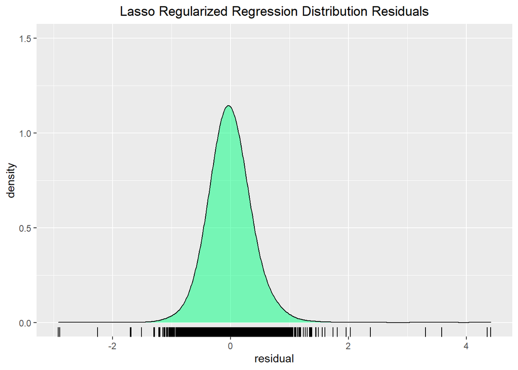

```r
# Generate predicted values for sales
lasso_test_preds <-
  lasso_wf_tuned %>%
  fit(data = data_train) %>%
  predict(data_test) %>%
  pull(.pred)

# Create tibble for distribution plot
lasso_pred <-
  tibble(observed = data_test$price,
         predicted = lasso_test_preds,
         residual = observed - predicted)

# Plot distribution residuals
lasso_residual_plot <-
  lasso_pred %>%
  ggplot(aes(x = residual)) +
  geom_density(bw = 0.15, fill = "springgreen", alpha = 0.5) +
  geom_rug() +
  labs(title = "Lasso Regularized Regression Distribution Residuals") +
  theme(plot.title = element_text(hjust = 0.5)) +
  coord_cartesian(ylim = c(0, 1.5))
lasso_residual_plot
```

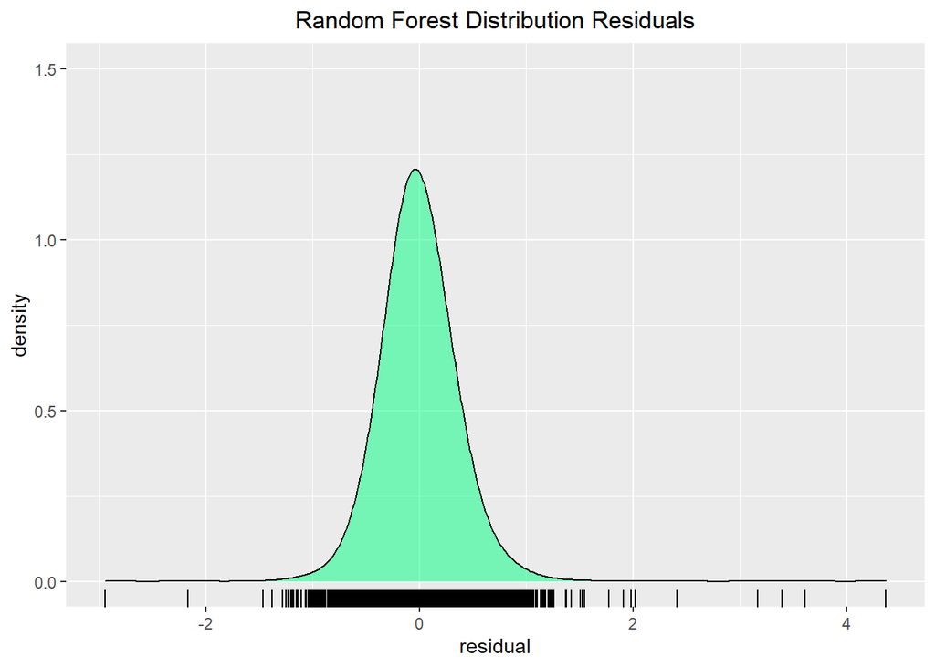

```r
# Generate predicted values for sales
set.seed(12345)
rf_test_preds <-
  rf_vi_wf %>%
  fit(data = data_train) %>%
  predict(data_test) %>%
  pull(.pred)

# Create tibble for distribution plot
rf_pred <-
  tibble(observed = data_test$price,
         predicted = rf_test_preds,
         residual = observed - predicted)

# Plot distribution residuals
rf_residual_plot <-
  rf_pred %>%
  ggplot(aes(x = residual)) +
  geom_density(bw = 0.15, fill = "springgreen", alpha = 0.5) +
  geom_rug() +
  labs(title = "Random Forest Distribution Residuals") +
  theme(plot.title = element_text(hjust = 0.5)) +
  coord_cartesian(ylim = c(0, 1.5))
rf_residual_plot
```

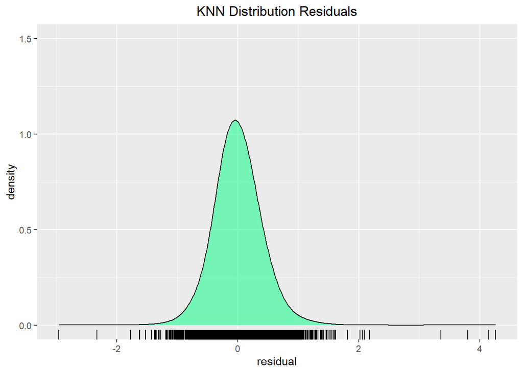

```r
# Generate predicted values for price
knn_test_preds <-
  knn_workflow_final %>%
  fit(data = data_train) %>%
  predict(data_test) %>%
  pull(.pred)

# Create tibble for distribution plot
knn_pred <-
  tibble(observed = data_test$price,
         predicted = knn_test_preds,
         residual = observed - predicted)

# Plot distribution residuals
knn_residual_plot <-
  knn_pred %>%
  ggplot(aes(x = residual)) +
  geom_density(bw = 0.15, fill = "springgreen", alpha = 0.5) +
  geom_rug() +
  labs(title = "KNN Distribution Residuals") +
  theme(plot.title = element_text(hjust = 0.5)) +
  coord_cartesian(ylim = c(0, 1.5))
knn_residual_plot
```

## Assessment metrics

The table below shows the results for the metrics for the three models. When assessing the metrics and their objectives, the results show that the random forest model performs best on all metrics. Therefore, the random forest is considered to be the best model.

```r
# Generate table with
lasso_metrics_compare <-
  lasso_test_metrics %>%
  select(-.estimator) %>%
  mutate(model = "lasso regression")
rf_metrics_compare <-
  final_res %>%
  collect_metrics() %>%
  mutate(model = "random forest")
knn_metrics_compare <-
  knn_last_fit %>%
  collect_metrics %>%
  select(-.estimator) %>%
  mutate(model = "knn reg")
lasso_metrics_compare %>%
  bind_rows(rf_metrics_compare, knn_metrics_compare) %>%
  select(-.estimator) %>%
  pivot_wider(names_from = .metric, values_from = .estimate)
```

| model | mae | rmse | rsq_trad |
| --- | --- | --- | --- |
| lasso regression | 0.2722283 | 0.3731941 | 0.4874893 |
| random forest | 0.2550743 | 0.3487327 | 0.5524733 |
| knn reg | 0.2930613 | 0.3965862 | 0.4212263 |

# **Part 4: Recommendations**

For this assignment, we assessed three models for predicting prices on the Airbnb platform. These three models are a lasso regularized linear regression, a random forest, and finally a K-Nearest Neighbours model. The models are assessed on three different metrics, namely the root mean square error (RMSE), the mean absolute error (MAE), and the r-squared. The proposed assessment metrics indicate that the random forest outperforms the lasso regularized linear regression and the K-Nearest-Neighbor in all proposed metrics.

How are these findings of use to Airbnb? Essentially, this project has sought to examine three approaches to competitively set listing prices of Airbnb listings. Considering our results, we advise Airbnb to use a random forest model in their projects that deal with optimal pricing of listings.